# 成分数据对相关系数的影响

Li Chenhao (李陈浩)

12/9/2017

# 写在前面

十分感谢刘老师的厚爱，向我约稿，本身我不是很擅长写教程之类面向多数人的东西。想了想，既然那天是由于对Co-occurence网络的讨论引起的，也正是自己课题的一部分，所以就分享一下这一部分的经验吧。本文的大部分内容都来自我们之前的一篇综述文章[Li et al, 2016](http://www.sciencedirect.com/science/article/pii/S1046202315300943?via%3Dihub)。

# 微生物组测序与成分数据

微生物组测序数据的获得其实有很多抽样过程（Sampling process）存在，比如说，粪便微生物组其实是对肠道微生物的一次抽样，测序的过程也是对所有DNA分子的一次抽样。最后，我们得到的OTU表中的OTU read count与测序深度相关，很显然测序深度是一个技术上的干扰因子（confounder），所以我们要对OTU表进行标准化（Normalization）。最简单的标准化方法，就是用read count除以样本内所有OTU的read count之和，获得每个OTU的相对丰度（relative abundance）。这种只有相对丰度的数据（相加总数为常数1或100）被称为成分数据（Compositional data）。 你可能注意到，作为成分数据一种的微生物组的数据中缺乏一个重要的信息–微生物总量（total abundance）。

# 成分之咒（Curse of compositionality）

### （一些推导的废话可以跳过）

成分数据会对一些列统计分析产生影响，最典型的就是计算相关系数（correlation）。其中Pearson相关系数$\rho_{X,Y}$是由协方差矩阵算出来的，对于两个OTU的数量（由随机变量$X$，$Y$表示），相关系数可以按下面公式计算（详细解释见[维基百科](https://en.wikipedia.org/wiki/Pearson_correlation_coefficient)）：

$$COV(X, Y)=E[(X-E[X])(Y-E[Y])]$$
$$\rho_{X,Y}=\frac{COV(X,Y)}{\sqrt{COV(X,X)\times COV(Y,Y)}}$$
其中$COV(X,X)$其实就是$X$的方差。其中根据协方差的性质我们可以得出成分数据的协方差性质：
$$\sum_{i=1}^px_i=1 \Rightarrow \sum_{i=1,i\neq r}^pCOV(x_i, x_r)=-COV(x_r, x_r)$$
我们知道方差（$COV(x_r, x_r)$）一定为正值，所以成分数据的协方差（同理相关系数）天然趋向于负值！

### 天然的负相关

上面的公式推导，其实简单的想一想，因为相加为1，所以一个OTU相对丰度增加，其他OTU必然减少，所以本来不相关的OTU数量在转化为成分数据后也会有负相关的趋势，也就是我们常见的微生物组领域所说的Compositional effect或Compositional bias。以下为简单的一个实验，Species 1和Speacies 2本来不相关，但是其相对丰度负相关：

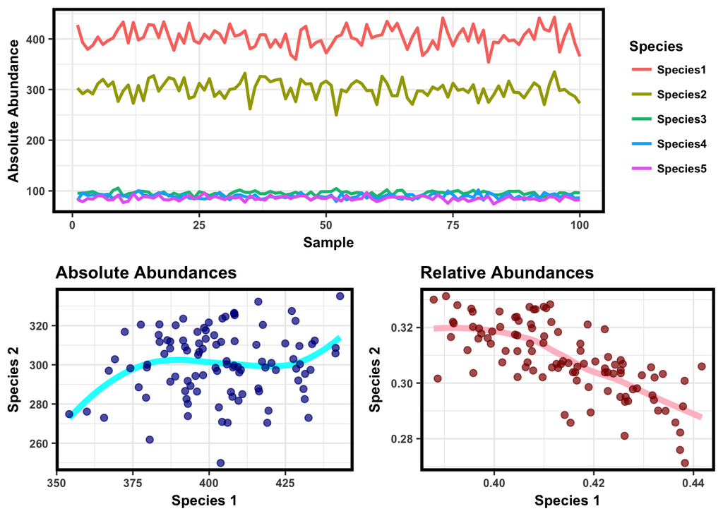

```r
## 加载r包
library(ggplot2)
library(reshape2)
library(cowplot)

## ggplot主题配置
figtheme <- theme_bw() + theme(text = element_text(size=10,face='bold'),panel.border  = element_rect(colour = "black",size=2))
theme_set(figtheme)

## 随机产生独立的5个OTU绝对数量
means <- c(400,300,95,90,85)
data <- sapply(means, function(x) rnorm(100, x, x*0.05))
colnames(data) <- c('Species1', 'Species2','Species3','Species4','Species5')

## 绝对数量的画图
data.long <- melt(data)
colnames(data.long) <- c('Sample','Species','Abundances')
p1 <- ggplot(data.long, aes(x=Sample, y=Abundances, group=Species, color=Species)) + geom_line(size=1) + labs(y='Absolute Abundance')
p2 <- ggplot(data.frame(data), aes(x=Species1, y=Species2)) + geom_smooth(se=F,size=2,col='cyan') + geom_point(alpha = .7, size=2, col='darkblue')  + labs(title='Absolute Abundances',x='Species 1', y='Species 2')

## 相对丰度
data.norm <- t(apply(data, 1, function(x) x/sum(x)))
data.norm.long <- melt(data.norm)
colnames(data.norm.long) <- c('Sample','Species','Abundances')
p3 <- ggplot(data.frame(data.norm), aes(x=Species1, y=Species2)) + geom_smooth(se=F,size=2,col='pink') + geom_point(alpha = .7, size=2, col='darkred') + labs(title='Relative Abundances',x='Species 1', y='Species 2')

plot_grid(p1,plot_grid(p2,p3, nrow=1), ncol=1)
```

成分之咒（Curse of compositionality）这个词出现于今年发表于Nature Biotechnology的一篇[综述文章](https://www.nature.com/articles/nbt.3935)，讲的就是成分数据对相关系数的影响。 我所阅读到最早在微生物组领域提出这个问题，并给出解决算法的两篇文章（[Faust et al](http://journals.plos.org/ploscompbiol/article?id=10.1371/journal.pcbi.1002606), [Friedman et al](http://journals.plos.org/ploscompbiol/article?id=10.1371/journal.pcbi.1002687)）都来自2012年的PLOS Computational Biology。这两篇文章可能你没有读过，但是他们都演化成了很有名的工具，前者就是R包[CCREPE](http://bioconductor.org/packages/release/bioc/html/ccrepe.html)和Cytoscape插件[CoNet](http://psbweb05.psb.ugent.be/conet/)，后者就是[SparCC](https://bitbucket.org/yonatanf/sparcc)。